# For the last workshop, we will work on a lung segmentation from CXR image

The data came from the Montgomery County TB dataset which consists of 58 positive and 80 normal cases

Lung segmentation masks are provide as a binary images

## Download the dataset using **wget** command

This may take ~6 minutes

```python
!wget http://openi.nlm.nih.gov/imgs/collections/NLM-MontgomeryCXRSet.zip
```

```
--2021-05-06 07:40:06--  http://openi.nlm.nih.gov/imgs/collections/NLM-MontgomeryCXRSet.zip
Resolving openi.nlm.nih.gov (openi.nlm.nih.gov)... 130.14.52.157, 2607:f220:41e:7052::157
Connecting to openi.nlm.nih.gov (openi.nlm.nih.gov)|130.14.52.157|:80... connected.
HTTP request sent, awaiting response... 301 Moved Permanently
Location: https://openi.nlm.nih.gov/imgs/collections/NLM-MontgomeryCXRSet.zip [following]
--2021-05-06 07:40:07--  https://openi.nlm.nih.gov/imgs/collections/NLM-MontgomeryCXRSet.zip
Connecting to openi.nlm.nih.gov (openi.nlm.nih.gov)|130.14.52.157|:443... connected.
HTTP request sent, awaiting response... 200 OK
Length: 616853875 (588M) [application/zip]
Saving to: ‘NLM-MontgomeryCXRSet.zip’

NLM-MontgomeryCXRSe 100%[===================>] 588.28M  1.44MB/s    in 6m 52s

2021-05-06 07:47:00 (1.43 MB/s) - ‘NLM-MontgomeryCXRSet.zip’ saved [616853875/616853875]
```

## Unzip the data

```python
!unzip NLM-MontgomeryCXRSet.zip
```

[output not shown]

[output cut: 519 more lines]

[output not shown]

## View the folder structure of the dataset

```python
!ls -la MontgomerySet
```

```
total 132
drwx------ 5 root root   4096 Sep 11  2014 .
drwxr-xr-x 1 root root   4096 May  6 07:47 ..
drwx------ 2 root root   4096 Sep  9  2014 ClinicalReadings
drwx------ 2 root root   4096 Sep  9  2014 CXR_png
-rwx------ 1 root root   6148 Sep 11  2014 .DS_Store
drwx------ 4 root root   4096 Sep  9  2014 ManualMask
-rwx------ 1 root root 104966 Sep 11  2014 NLM-MontgomeryCXRSet-ReadMe.pdf
```

```python
!ls MontgomerySet/CXR_png
```

```
MCUCXR_0001_0.png  MCUCXR_0049_0.png  MCUCXR_0092_0.png  MCUCXR_0251_1.png
MCUCXR_0002_0.png  MCUCXR_0051_0.png  MCUCXR_0094_0.png  MCUCXR_0253_1.png
MCUCXR_0003_0.png  MCUCXR_0052_0.png  MCUCXR_0095_0.png  MCUCXR_0254_1.png
MCUCXR_0004_0.png  MCUCXR_0053_0.png  MCUCXR_0096_0.png  MCUCXR_0255_1.png
MCUCXR_0005_0.png  MCUCXR_0054_0.png  MCUCXR_0097_0.png  MCUCXR_0258_1.png
MCUCXR_0006_0.png  MCUCXR_0055_0.png  MCUCXR_0099_0.png  MCUCXR_0264_1.png
MCUCXR_0008_0.png  MCUCXR_0056_0.png  MCUCXR_0100_0.png  MCUCXR_0266_1.png
MCUCXR_0011_0.png  MCUCXR_0057_0.png  MCUCXR_0101_0.png  MCUCXR_0275_1.png
MCUCXR_0013_0.png  MCUCXR_0058_0.png  MCUCXR_0102_0.png  MCUCXR_0282_1.png
MCUCXR_0015_0.png  MCUCXR_0059_0.png  MCUCXR_0103_0.png  MCUCXR_0289_1.png
MCUCXR_0016_0.png  MCUCXR_0060_0.png  MCUCXR_0104_1.png  MCUCXR_0294_1.png
MCUCXR_0017_0.png  MCUCXR_0061_0.png  MCUCXR_0108_1.png  MCUCXR_0301_1.png
MCUCXR_0019_0.png  MCUCXR_0062_0.png  MCUCXR_0113_1.png  MCUCXR_0309_1.png
MCUCXR_0020_0.png  MCUCXR_0063_0.png  MCUCXR_0117_1.png  MCUCXR_0311_1.png
MCUCXR_0021_0.png  MCUCXR_0064_0.png  MCUCXR_0126_1.png  MCUCXR_0313_1.png
MCUCXR_0022_0.png  MCUCXR_0068_0.png  MCUCXR_0140_1.png  MCUCXR_0316_1.png
MCUCXR_0023_0.png  MCUCXR_0069_0.png  MCUCXR_0141_1.png  MCUCXR_0331_1.png
MCUCXR_0024_0.png  MCUCXR_0070_0.png  MCUCXR_0142_1.png  MCUCXR_0334_1.png
MCUCXR_0026_0.png  MCUCXR_0071_0.png  MCUCXR_0144_1.png  MCUCXR_0338_1.png
MCUCXR_0027_0.png  MCUCXR_0072_0.png  MCUCXR_0150_1.png  MCUCXR_0348_1.png
MCUCXR_0028_0.png  MCUCXR_0074_0.png  MCUCXR_0162_1.png  MCUCXR_0350_1.png
MCUCXR_0029_0.png  MCUCXR_0075_0.png  MCUCXR_0166_1.png  MCUCXR_0352_1.png
MCUCXR_0030_0.png  MCUCXR_0077_0.png  MCUCXR_0170_1.png  MCUCXR_0354_1.png
MCUCXR_0031_0.png  MCUCXR_0079_0.png  MCUCXR_0173_1.png  MCUCXR_0362_1.png
MCUCXR_0035_0.png  MCUCXR_0080_0.png  MCUCXR_0182_1.png  MCUCXR_0367_1.png
MCUCXR_0038_0.png  MCUCXR_0081_0.png  MCUCXR_0188_1.png  MCUCXR_0369_1.png
MCUCXR_0040_0.png  MCUCXR_0082_0.png  MCUCXR_0194_1.png  MCUCXR_0372_1.png
MCUCXR_0041_0.png  MCUCXR_0083_0.png  MCUCXR_0195_1.png  MCUCXR_0375_1.png
MCUCXR_0042_0.png  MCUCXR_0084_0.png  MCUCXR_0196_1.png  MCUCXR_0383_1.png
MCUCXR_0043_0.png  MCUCXR_0085_0.png  MCUCXR_0203_1.png  MCUCXR_0387_1.png
MCUCXR_0044_0.png  MCUCXR_0086_0.png  MCUCXR_0213_1.png  MCUCXR_0390_1.png
MCUCXR_0045_0.png  MCUCXR_0087_0.png  MCUCXR_0218_1.png  MCUCXR_0393_1.png
MCUCXR_0046_0.png  MCUCXR_0089_0.png  MCUCXR_0223_1.png  MCUCXR_0399_1.png
MCUCXR_0047_0.png  MCUCXR_0090_0.png  MCUCXR_0228_1.png  Thumbs.db
MCUCXR_0048_0.png  MCUCXR_0091_0.png  MCUCXR_0243_1.png
```

```python
!ls MontgomerySet/ManualMask/leftMask
```

```
MCUCXR_0001_0.png  MCUCXR_0049_0.png  MCUCXR_0092_0.png  MCUCXR_0251_1.png
MCUCXR_0002_0.png  MCUCXR_0051_0.png  MCUCXR_0094_0.png  MCUCXR_0253_1.png
MCUCXR_0003_0.png  MCUCXR_0052_0.png  MCUCXR_0095_0.png  MCUCXR_0254_1.png
MCUCXR_0004_0.png  MCUCXR_0053_0.png  MCUCXR_0096_0.png  MCUCXR_0255_1.png
MCUCXR_0005_0.png  MCUCXR_0054_0.png  MCUCXR_0097_0.png  MCUCXR_0258_1.png
MCUCXR_0006_0.png  MCUCXR_0055_0.png  MCUCXR_0099_0.png  MCUCXR_0264_1.png
MCUCXR_0008_0.png  MCUCXR_0056_0.png  MCUCXR_0100_0.png  MCUCXR_0266_1.png
MCUCXR_0011_0.png  MCUCXR_0057_0.png  MCUCXR_0101_0.png  MCUCXR_0275_1.png
MCUCXR_0013_0.png  MCUCXR_0058_0.png  MCUCXR_0102_0.png  MCUCXR_0282_1.png
MCUCXR_0015_0.png  MCUCXR_0059_0.png  MCUCXR_0103_0.png  MCUCXR_0289_1.png
MCUCXR_0016_0.png  MCUCXR_0060_0.png  MCUCXR_0104_1.png  MCUCXR_0294_1.png
MCUCXR_0017_0.png  MCUCXR_0061_0.png  MCUCXR_0108_1.png  MCUCXR_0301_1.png
MCUCXR_0019_0.png  MCUCXR_0062_0.png  MCUCXR_0113_1.png  MCUCXR_0309_1.png
MCUCXR_0020_0.png  MCUCXR_0063_0.png  MCUCXR_0117_1.png  MCUCXR_0311_1.png
MCUCXR_0021_0.png  MCUCXR_0064_0.png  MCUCXR_0126_1.png  MCUCXR_0313_1.png
MCUCXR_0022_0.png  MCUCXR_0068_0.png  MCUCXR_0140_1.png  MCUCXR_0316_1.png
MCUCXR_0023_0.png  MCUCXR_0069_0.png  MCUCXR_0141_1.png  MCUCXR_0331_1.png
MCUCXR_0024_0.png  MCUCXR_0070_0.png  MCUCXR_0142_1.png  MCUCXR_0334_1.png
MCUCXR_0026_0.png  MCUCXR_0071_0.png  MCUCXR_0144_1.png  MCUCXR_0338_1.png
MCUCXR_0027_0.png  MCUCXR_0072_0.png  MCUCXR_0150_1.png  MCUCXR_0348_1.png
MCUCXR_0028_0.png  MCUCXR_0074_0.png  MCUCXR_0162_1.png  MCUCXR_0350_1.png
MCUCXR_0029_0.png  MCUCXR_0075_0.png  MCUCXR_0166_1.png  MCUCXR_0352_1.png
MCUCXR_0030_0.png  MCUCXR_0077_0.png  MCUCXR_0170_1.png  MCUCXR_0354_1.png
MCUCXR_0031_0.png  MCUCXR_0079_0.png  MCUCXR_0173_1.png  MCUCXR_0362_1.png
MCUCXR_0035_0.png  MCUCXR_0080_0.png  MCUCXR_0182_1.png  MCUCXR_0367_1.png
MCUCXR_0038_0.png  MCUCXR_0081_0.png  MCUCXR_0188_1.png  MCUCXR_0369_1.png
MCUCXR_0040_0.png  MCUCXR_0082_0.png  MCUCXR_0194_1.png  MCUCXR_0372_1.png
MCUCXR_0041_0.png  MCUCXR_0083_0.png  MCUCXR_0195_1.png  MCUCXR_0375_1.png
MCUCXR_0042_0.png  MCUCXR_0084_0.png  MCUCXR_0196_1.png  MCUCXR_0383_1.png
MCUCXR_0043_0.png  MCUCXR_0085_0.png  MCUCXR_0203_1.png  MCUCXR_0387_1.png
MCUCXR_0044_0.png  MCUCXR_0086_0.png  MCUCXR_0213_1.png  MCUCXR_0390_1.png
MCUCXR_0045_0.png  MCUCXR_0087_0.png  MCUCXR_0218_1.png  MCUCXR_0393_1.png
MCUCXR_0046_0.png  MCUCXR_0089_0.png  MCUCXR_0223_1.png  MCUCXR_0399_1.png
MCUCXR_0047_0.png  MCUCXR_0090_0.png  MCUCXR_0228_1.png  Thumbs.db
MCUCXR_0048_0.png  MCUCXR_0091_0.png  MCUCXR_0243_1.png
```

## Import libraries

```python
import matplotlib.pyplot as plt
import numpy as np
import os

from sklearn.model_selection import train_test_split

from tensorflow.keras.models import Model, Sequential

from tensorflow.keras.optimizers import Adam
from tensorflow.keras.callbacks import TensorBoard, ModelCheckpoint, ReduceLROnPlateau

import tensorflow as tf
import tensorflow.keras.layers as layers
```

## Let's view some images to understand the data

Each set of data consist of 3 images: CXR, the mask for left lung, and the mask for right lung

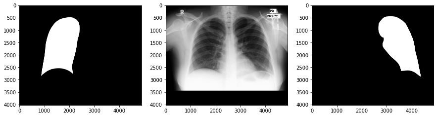

```python
image_name = 'MCUCXR_0001_0.png'

plt.figure(figsize = (15, 5))
plt.subplot(1, 3, 1); plt.imshow(plt.imread('MontgomerySet/ManualMask/leftMask/' + image_name), cmap = 'gray')
plt.subplot(1, 3, 2); plt.imshow(plt.imread('MontgomerySet/CXR_png/' + image_name), cmap = 'gray')
plt.subplot(1, 3, 3); plt.imshow(plt.imread('MontgomerySet/ManualMask/rightMask/' + image_name), cmap = 'gray')
plt.show()
```

### We can overlay the three images by manipulating the pixel array

Grayscale image is a 2D array with pixel values in [0, 1] when read with **plt.imread()**

```python
left_lung = plt.imread('MontgomerySet/ManualMask/leftMask/' + image_name)
right_lung = plt.imread('MontgomerySet/ManualMask/rightMask/' + image_name)
cxr = plt.imread('MontgomerySet/CXR_png/' + image_name)

print('CXR grayscale image is just a 2D array with shape:', cxr.shape)
```

```
CXR grayscale image is just a 2D array with shape: (4020, 4892)
```

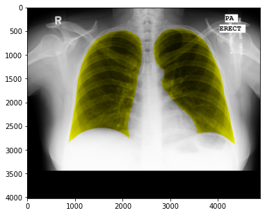

```python
combined_mask = left_lung + right_lung
overlayed = cxr.reshape([cxr.shape[0], cxr.shape[1], 1])
overlayed = np.concatenate([overlayed, overlayed, overlayed], axis = 2)
overlayed[:, :, 2] = np.multiply(1 - combined_mask, overlayed[:, :, 2])

plt.figure(figsize = (6, 6))
plt.imshow(overlayed)
plt.show()
```

## Define a U-Net model using MobileNetV2 as the encoder

Recall that U-Net's structure consists of a **CNN-based encoder** followed by a **series of upsampling layers**, with **gradient shortcuts** connecting each convolutional layer to the corresponding upsampling layer

### Let's view the structure of MobileNetV2

```python
encoder = tf.keras.applications.MobileNetV2(input_shape = [224, 224, 3], weights = 'imagenet', include_top = False)
encoder.summary()
```

```
Model: "mobilenetv2_1.00_224"
__________________________________________________________________________________________________
Layer (type)                    Output Shape         Param #     Connected to
==================================================================================================
input_2 (InputLayer)            [(None, 224, 224, 3) 0
__________________________________________________________________________________________________
Conv1 (Conv2D)                  (None, 112, 112, 32) 864         input_2[0][0]
__________________________________________________________________________________________________
bn_Conv1 (BatchNormalization)   (None, 112, 112, 32) 128         Conv1[0][0]
__________________________________________________________________________________________________
Conv1_relu (ReLU)               (None, 112, 112, 32) 0           bn_Conv1[0][0]
__________________________________________________________________________________________________
expanded_conv_depthwise (Depthw (None, 112, 112, 32) 288         Conv1_relu[0][0]
__________________________________________________________________________________________________
expanded_conv_depthwise_BN (Bat (None, 112, 112, 32) 128         expanded_conv_depthwise[0][0]
__________________________________________________________________________________________________
expanded_conv_depthwise_relu (R (None, 112, 112, 32) 0           expanded_conv_depthwise_BN[0][0]
__________________________________________________________________________________________________
expanded_conv_project (Conv2D)  (None, 112, 112, 16) 512         expanded_conv_depthwise_relu[0][0
__________________________________________________________________________________________________
expanded_conv_project_BN (Batch (None, 112, 112, 16) 64          expanded_conv_project[0][0]
__________________________________________________________________________________________________
block_1_expand (Conv2D)         (None, 112, 112, 96) 1536        expanded_conv_project_BN[0][0]
__________________________________________________________________________________________________
block_1_expand_BN (BatchNormali (None, 112, 112, 96) 384         block_1_expand[0][0]
__________________________________________________________________________________________________
block_1_expand_relu (ReLU)      (None, 112, 112, 96) 0           block_1_expand_BN[0][0]
__________________________________________________________________________________________________
block_1_pad (ZeroPadding2D)     (None, 113, 113, 96) 0           block_1_expand_relu[0][0]
__________________________________________________________________________________________________
block_1_depthwise (DepthwiseCon (None, 56, 56, 96)   864         block_1_pad[0][0]
__________________________________________________________________________________________________
block_1_depthwise_BN (BatchNorm (None, 56, 56, 96)   384         block_1_depthwise[0][0]
__________________________________________________________________________________________________
block_1_depthwise_relu (ReLU)   (None, 56, 56, 96)   0           block_1_depthwise_BN[0][0]
__________________________________________________________________________________________________
block_1_project (Conv2D)        (None, 56, 56, 24)   2304        block_1_depthwise_relu[0][0]
__________________________________________________________________________________________________
block_1_project_BN (BatchNormal (None, 56, 56, 24)   96          block_1_project[0][0]
__________________________________________________________________________________________________
```

[output cut: 271 more lines]

```
__________________________________________________________________________________________________
block_16_project (Conv2D)       (None, 7, 7, 320)    307200      block_16_depthwise_relu[0][0]
__________________________________________________________________________________________________
block_16_project_BN (BatchNorma (None, 7, 7, 320)    1280        block_16_project[0][0]
__________________________________________________________________________________________________
Conv_1 (Conv2D)                 (None, 7, 7, 1280)   409600      block_16_project_BN[0][0]
__________________________________________________________________________________________________
Conv_1_bn (BatchNormalization)  (None, 7, 7, 1280)   5120        Conv_1[0][0]
__________________________________________________________________________________________________
out_relu (ReLU)                 (None, 7, 7, 1280)   0           Conv_1_bn[0][0]
==================================================================================================
Total params: 2,257,984
Trainable params: 2,223,872
Non-trainable params: 34,112
__________________________________________________________________________________________________
```

### Generate a list of layer outputs for sending to the corresponding upsampling layers

We want the output from the last **ReLU activation** layer before the image size decrease each time

1. **block_1_expand_relu** before the image size goes from 112 to 56
2. **block_3_expand_relu** before the image size goes from 56 to 28
3. **block_6_expand_relu** before the image size goes from 28 to 14
4. **block_13_expand_relu** before the image size goes from 14 to 7
5. **block_16_project** which is the last layer of the encoder (the rest of MobileNetV2 is for decoding outputs)

```python
encoder_output_layer_names = ['block_1_expand_relu', 'block_3_expand_relu', 'block_6_expand_relu', 'block_13_expand_relu', 'block_16_project']
encoder_outputs = [encoder.get_layer(name).output for name in encoder_output_layer_names]
```

## Define the encoder portion of our U-Net model

Also freeze its weights

```python
unet_encoder = tf.keras.Model(inputs = encoder.input, outputs = encoder_outputs)
unet_encoder.trainable = False
```

## For the upsampling part, we will use a predefined pix2pix architecture in TensorFlow

```python
!pip install -q git+https://github.com/tensorflow/examples.git
from tensorflow_examples.models.pix2pix import pix2pix

decoder = [pix2pix.upsample(512, 3),  # 7x7 -> 14x14
           pix2pix.upsample(256, 3),  # 14x14 -> 28x28
           pix2pix.upsample(128, 3),  # 28x28 -> 56x56
           pix2pix.upsample(64, 3)   # 56x56 -> 112x112
          ]
```

## Put together the whole architecture

```python
def generate_unet():
    inputs = layers.Input(shape = [224, 224, 3])

    skips = unet_encoder(inputs) ## outputs of the encoder, ordered from top to bottom
    x = skips[-1] ## this is the bottommost output of the encoder
    skips = reversed(skips[:-1]) ## reverse the order of the outputs from bottom to top

    for up_layer, skip in zip(decoder, skips):
        x = up_layer(x)
        x = layers.Concatenate()([x, skip]) ## connect each output from the encoder to the corresponding upsampling layer

    x = layers.Conv2DTranspose(filters = 1, kernel_size = 3, strides = 2, padding = 'same')(x) ## the last upsampling
    output = layers.Activation(activation = 'sigmoid')(x)

    return Model(inputs = inputs, outputs = output)
```

### Confirm the architecture of our model

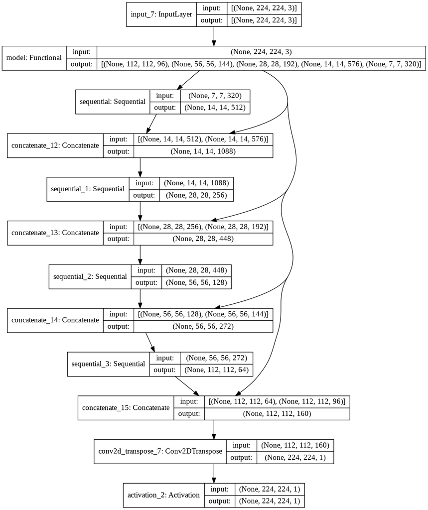

```python
model = generate_unet()
tf.keras.utils.plot_model(model, show_shapes = True)
```

## Prepare the dataset using TensorFlow's Dataset interface

Previously, we have been loading the entire datasets into the memory. But this would be impossible for large dataset. With TensorFlow's Dataset interface, we can load and process the data for each batch as we need them.

### This will be our pipeline for preprocessing data

1. Obtain a list of CXR file names to be loaded for this batch
2. Load CXR images and resize them to 224x224x3
3. Load left and right lung masks, combine them, and resize to 224x224x1
4. Feed the resulting (CXR, mask) pairs to the model

```python
all_cxr_filenames = [f for f in os.listdir('MontgomerySet/CXR_png') if f.endswith('.png')]
print('first five images:', all_cxr_filenames[:5])
```

```
first five images: ['MCUCXR_0035_0.png', 'MCUCXR_0372_1.png', 'MCUCXR_0362_1.png', 'MCUCXR_0166_1.png', 'MCUCXR_0049_0.png']
```

```python
X_train, X_test = train_test_split(all_cxr_filenames, test_size = 0.2, shuffle = True, random_state = 3011979)
X_train, X_val = train_test_split(X_train, test_size = 0.2, shuffle = True, random_state = 3011979)
```

## Define a function for performing the outlined preprocessing tasks

```python
def load_and_resize(filename):
    try:
        bits = tf.io.read_file('MontgomerySet/CXR_png/' + filename)
        image = tf.image.decode_png(bits, channels = 3)

        image = tf.cast(image, dtype = tf.float32)
        image = image / tf.reduce_max(image, axis = None)
        dim = tf.shape(image)

        h_margin = tf.math.divide(tf.math.maximum(tf.math.subtract(dim[0], dim[1]) // 2, 0), dim[0])
        w_margin = tf.math.divide(tf.math.maximum(tf.math.subtract(dim[1], dim[0]) // 2, 0), dim[1])

        image = tf.image.crop_and_resize([image], \
                                         boxes = [[h_margin, w_margin, 1 - h_margin, 1 - w_margin]], \
                                         box_indices = [0], crop_size = [224, 224])[0, :]

        bits = tf.io.read_file('MontgomerySet/ManualMask/leftMask/' + filename)
        left_mask = tf.image.decode_png(bits, channels = 1)

        bits = tf.io.read_file('MontgomerySet/ManualMask/rightMask/' + filename)
        right_mask = tf.image.decode_png(bits, channels = 1)

        combined_mask = tf.math.add(left_mask, right_mask)
        combined_mask = tf.cast(combined_mask, dtype = tf.float32)
        combined_mask = combined_mask / tf.reduce_max(combined_mask, axis = None)

        combined_mask = tf.image.crop_and_resize([combined_mask], \
                                                 boxes = [[h_margin, w_margin, 1 - h_margin, 1 - w_margin]], \
                                                 box_indices = [0], crop_size = [224, 224])[0, :]

        return image, combined_mask

    except:
        print('cannot preprocess:', filename)
```

## Now, we are ready to define the training, validation, and test datasets via Dataset interface

```python
batch_size = 32
AUTO = tf.data.experimental.AUTOTUNE
```

```python
train_dataset = (
    tf.data.Dataset
    .from_tensor_slices((X_train))
    .map(load_and_resize, num_parallel_calls = AUTO)
    .shuffle(512)
    .batch(batch_size)
    )

val_dataset = (
    tf.data.Dataset
    .from_tensor_slices((X_val))
    .map(load_and_resize, num_parallel_calls = AUTO)
    .batch(batch_size)
    )

test_dataset = (
    tf.data.Dataset
    .from_tensor_slices((X_test))
    .map(load_and_resize, num_parallel_calls = AUTO)
    .batch(batch_size)
    )
```

### Test whether the pipeline work correctly by generating a batch and visualize the first (CXR, mask) pair

```python
def view_overlay(cxr, mask):
    overlayed = cxr
    overlayed[:, :, 2] = np.multiply(1 - (mask[:, :, 0] > 0.5), overlayed[:, :, 2])

    plt.figure(figsize = (6, 6))
    plt.imshow(overlayed)
    plt.show()
```

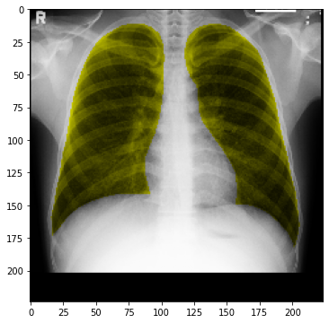

```python
X_batch, y_batch = next(iter(train_dataset))
view_overlay(X_batch[0].numpy(), y_batch[0].numpy())
```

## Let's predict some masks

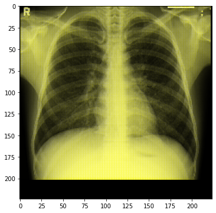

```python
predicted_masks = model.predict(X_batch)
view_overlay(X_batch[0].numpy(), predicted_masks[0])
```

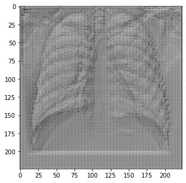

```python
plt.figure(figsize = (5, 5))
plt.imshow(predicted_masks[0][:, :, 0], cmap = 'gray')
plt.show()
```

## Define callbacks

```python
modelckpt_callback = ModelCheckpoint('mobilenetv2_imagenet_pix2pix_montgomery.ckpt', \
                                     verbose = 1, save_best_only = True, save_weights_only = True)
tensorboard_callback = TensorBoard('mobilenetv2_imagenet_pix2pix_montgomery.tb', histogram_freq = 1)
reduced_lr_callback = ReduceLROnPlateau(patience = 5, factor = 0.2)

epochs = 200
```

## Start TensorBoard instance

```python
# !rm -r mobilenetv2_imagenet_pix2pix_montgomery.tb
```

```python
%load_ext tensorboard
%tensorboard --logdir mobilenetv2_imagenet_pix2pix_montgomery.tb
```

## Train the model

```python
model = generate_unet()
model.compile(optimizer = Adam(learning_rate = 1e-4),
              loss = tf.keras.losses.BinaryCrossentropy(),
              metrics = ['accuracy'])
```

```python
tf.random.set_seed(3011979)
history = model.fit(train_dataset, validation_data = valid_dataset, \
                    epochs = epochs, callbacks = [modelckpt_callback, tensorboard_callback, reduced_lr_callback], \
                    verbose = 1, shuffle = True)
```

```
Epoch 00001: val_loss improved from inf to 0.66063, saving model to mobilenetv2_imagenet_pix2pix_montgomery.ckpt

Epoch 00002: val_loss improved from 0.66063 to 0.64456, saving model to mobilenetv2_imagenet_pix2pix_montgomery.ckpt

Epoch 00003: val_loss improved from 0.64456 to 0.63197, saving model to mobilenetv2_imagenet_pix2pix_montgomery.ckpt

Epoch 00004: val_loss improved from 0.63197 to 0.62228, saving model to mobilenetv2_imagenet_pix2pix_montgomery.ckpt

Epoch 00005: val_loss improved from 0.62228 to 0.60914, saving model to mobilenetv2_imagenet_pix2pix_montgomery.ckpt

Epoch 00006: val_loss improved from 0.60914 to 0.59298, saving model to mobilenetv2_imagenet_pix2pix_montgomery.ckpt

Epoch 00007: val_loss improved from 0.59298 to 0.57926, saving model to mobilenetv2_imagenet_pix2pix_montgomery.ckpt

Epoch 00008: val_loss improved from 0.57926 to 0.56705, saving model to mobilenetv2_imagenet_pix2pix_montgomery.ckpt

Epoch 00009: val_loss improved from 0.56705 to 0.55471, saving model to mobilenetv2_imagenet_pix2pix_montgomery.ckpt

Epoch 00010: val_loss improved from 0.55471 to 0.54299, saving model to mobilenetv2_imagenet_pix2pix_montgomery.ckpt

Epoch 00011: val_loss improved from 0.54299 to 0.53184, saving model to mobilenetv2_imagenet_pix2pix_montgomery.ckpt

Epoch 00012: val_loss improved from 0.53184 to 0.51719, saving model to mobilenetv2_imagenet_pix2pix_montgomery.ckpt

Epoch 00013: val_loss improved from 0.51719 to 0.50688, saving model to mobilenetv2_imagenet_pix2pix_montgomery.ckpt

Epoch 00014: val_loss improved from 0.50688 to 0.49713, saving model to mobilenetv2_imagenet_pix2pix_montgomery.ckpt

Epoch 00015: val_loss improved from 0.49713 to 0.48624, saving model to mobilenetv2_imagenet_pix2pix_montgomery.ckpt

Epoch 00016: val_loss improved from 0.48624 to 0.47499, saving model to mobilenetv2_imagenet_pix2pix_montgomery.ckpt

Epoch 00017: val_loss improved from 0.47499 to 0.46655, saving model to mobilenetv2_imagenet_pix2pix_montgomery.ckpt

Epoch 00018: val_loss improved from 0.46655 to 0.45607, saving model to mobilenetv2_imagenet_pix2pix_montgomery.ckpt

Epoch 00019: val_loss improved from 0.45607 to 0.44611, saving model to mobilenetv2_imagenet_pix2pix_montgomery.ckpt

Epoch 00020: val_loss improved from 0.44611 to 0.43818, saving model to mobilenetv2_imagenet_pix2pix_montgomery.ckpt

```

[output cut: 244 more lines]

```
Epoch 00143: val_loss did not improve from 0.13667

Epoch 00144: val_loss did not improve from 0.13667

Epoch 00145: val_loss improved from 0.13667 to 0.13507, saving model to mobilenetv2_imagenet_pix2pix_montgomery.ckpt

Epoch 00146: val_loss did not improve from 0.13507

Epoch 00147: val_loss improved from 0.13507 to 0.13388, saving model to mobilenetv2_imagenet_pix2pix_montgomery.ckpt

Epoch 00148: val_loss did not improve from 0.13388

Epoch 00149: val_loss did not improve from 0.13388

Epoch 00150: val_loss improved from 0.13388 to 0.13347, saving model to mobilenetv2_imagenet_pix2pix_montgomery.ckpt
```

[output not shown]

## Let's see how to trained model predict mask

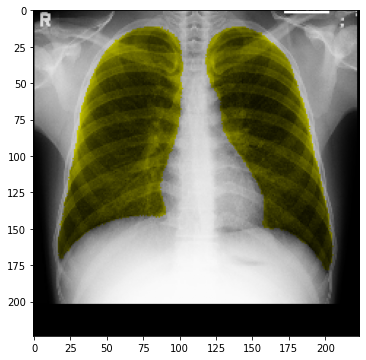

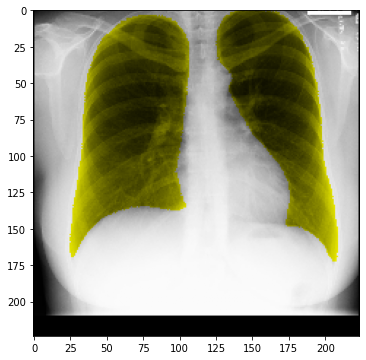

```python
predicted_masks = model.predict(X_batch)
view_overlay(X_batch[0].numpy(), predicted_masks[0])
view_overlay(X_batch[1].numpy(), predicted_masks[1])
```

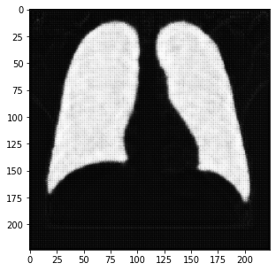

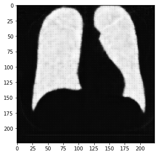

```python
plt.figure(figsize = (5, 5))
plt.imshow(predicted_masks[0][:, :, 0], cmap = 'gray')
plt.show()

plt.figure(figsize = (5, 5))
plt.imshow(predicted_masks[1][:, :, 0], cmap = 'gray')
plt.show()
```